# R Notebook

```r
library(dplyr)
library(readr)
```

```r
library(ggplot2)
library(tidyr)
library(lubridate)
library(stringr)
library(forcats)
library(purrr)
library(tibble)
library(httr)
library(shiny)
library(ggdark)
library(xgboost)
```

COMBINE All rounder, batsman and bowling data together

```r
bat_t20 <- read_csv("C:/Users/vibha/OneDrive/HPA_Project/t20_batting.csv")
bowl_t20 <- read_csv("C:/Users/vibha/OneDrive/HPA_Project/t20_bowling.csv")
allr_t20 <- read.csv("C:/Users/vibha/OneDrive/HPA_Project/t20_all_round.csv")


all_player <- read_csv("C:/Users/vibha/OneDrive/HPA_Project/all_players.csv")
country <- read_csv("C:/Users/vibha/OneDrive/HPA_Project/country.csv")
# unique identifiers
all(n_distinct(bat_t20$id) == nrow(bat_t20))
```

```
## [1] TRUE
```

```r
all(n_distinct(bowl_t20$id) == nrow(bowl_t20))
```

```
## [1] TRUE
```

```r
all(n_distinct(allr_t20$id) == nrow(allr_t20))
```

```
## [1] TRUE
```

```r
# Merging batting, bowling and all rounder datasets by player ID
t20_combined_bat_bowl <- merge(bat_t20, bowl_t20, by = "id", all = TRUE)
t20_combined_all <- merge(t20_combined_bat_bowl, allr_t20, by = "id", all = TRUE)
head(t20_combined_all)
```

|  | id | span | matches | innings | not_out | runs | high_score | average_score | ball_faced | strike_rate | 100s | 50 | 0s | 4s | 6s | sp.x | bbi.x | bbm | bl | bwa.x | bwe | bwsr | cd | fw.x | fwk | in | md | mt | ov | … |
| --- | --- | --- | --- | --- | --- | --- | --- | --- | --- | --- | --- | --- | --- | --- | --- | --- | --- | --- | --- | --- | --- | --- | --- | --- | --- | --- | --- | --- | --- | --- |
| 1 | 5334 | 2011-2022 | 103 | 103 | 12 | 3120 | 172 | 34.28 | 2189 | 142.53 | 2 | 19 | 8 | 309 | 125 | 2013-2022 | 2-Jan | 2-Jan | NA | 64.75 | 5.47 | 71.0 | 259 | 0 | 0 | 21 | 0 | 146 | 47.2 | … |
| 2 | 8608 | 2007-2009 | 19 | 4 | 3 | 1 | 1* | 1.00 | 2 | 50.00 | 0 | 0 | 1 | 0 | 0 | 2002-2015 | 23-May | 23-May | NA | 29.22 | 4.92 | 35.6 | 7861 | 2 | 11 | 191 | 125 | 194 | 1597.2 | … |
| 3 | 8917 | 2014-2022 | 71 | 61 | 15 | 1044 | 72* | 22.69 | 716 | 145.81 | 0 | 7 | 9 | 82 | 55 | 2014-2023 | Apr-46 | Apr-46 | NA | 50.31 | 5.31 | 56.8 | 4830 | 0 | 1 | 116 | 11 | 126 | 909.0 | … |
| 4 | 10617 | 2006-2014 | 56 | 26 | 10 | 118 | 18* | 7.37 | 118 | 100.00 | 0 | 0 | 2 | 7 | 3 | 2006-2016 | 23-May | 23-May | NA | 30.13 | 5.26 | 34.3 | 5364 | 1 | 9 | 121 | 56 | 121 | 1018.1 | … |
| 5 | 24598 | 2009-2022 | 115 | 107 | 21 | 2458 | 91 | 28.58 | 1805 | 136.17 | 0 | 14 | 3 | 186 | 120 | 2006-2022 | NA | NA | NA | NA | NA | NA | NA | NA | NA | NA | NA | 248 | NA | … |
| 6 | 25913 | 2010-2022 | 104 | 96 | 16 | 1686 | 89 | 21.07 | 1204 | 140.03 | 0 | 4 | 6 | 114 | 89 | 2009-2022 | 30-Apr | 30-Apr | NA | 32.13 | 4.28 | 44.9 | 4628 | 0 | 4 | 131 | 43 | 136 | 1079.3 | … |

combine all player and country with id

```r
all_players_with_country <- left_join(all_player, country, by = c("country_id" = "id"))

head(all_players_with_country)
```

| id | name | gender | bating_style | bowling_style | playing_role | country_id | country |
| --- | --- | --- | --- | --- | --- | --- | --- |
| 935995 | Afif Hossain | M | left-hand bat | right-arm offbreak | allrounder | 25 | Bangladesh |
| 380354 | Anamul Haque | M | right-hand bat | NA | wicketkeeper batter | 25 | Bangladesh |
| 1346729 | Dilara Akter | F | right-hand bat | NA | wicketkeeper batter | 25 | Bangladesh |
| 932355 | Ebadot Hossain | M | right-hand bat | right-arm fast-medium | bowler | 25 | Bangladesh |
| 627048 | Fahima Khatun | F | right-hand bat | legbreak | bowler | 25 | Bangladesh |
| 486995 | Fargana Hoque | M | right-hand bat | NA | top-order batter | 25 | Bangladesh |

```r
t20_combined_all <- left_join(t20_combined_all, all_players_with_country, by = "id")
```

rename the columns

```r
t20_combined_all <- t20_combined_all %>%
  rename_with(~gsub("\\.x$", "_bowling", .), ends_with(".x")) %>%
  rename_with(~gsub("\\.y$", "_allrounder", .), ends_with(".y"))

colnames(t20_combined_all)
```

```
##  [1] "id"             "span"           "matches"        "innings"
##  [5] "not_out"        "runs"           "high_score"     "average_score"
##  [9] "ball_faced"     "strike_rate"    "100s"           "50"
## [13] "0s"             "4s"             "6s"             "sp_bowling"
## [17] "bbi_bowling"    "bbm"            "bl"             "bwa_bowling"
## [21] "bwe"            "bwsr"           "cd"             "fw_bowling"
## [25] "fwk"            "in"             "md"             "mt"
## [29] "ov"             "pr_bowling"     "tw"             "wk_bowling"
## [33] "bbad"           "bbi_allrounder" "bta"            "bwa_allrounder"
## [37] "ct"             "fw_allrounder"  "hn"             "hs"
## [41] "pr_allrounder"  "rn"             "st"             "wk_allrounder"
## [45] "sp_allrounder"  "name"           "gender"         "bating_style"
## [49] "bowling_style"  "playing_role"   "country_id"     "country"
```

```r
#write_csv(t20_combined_all, "C:/Users/vibha/OneDrive/HPA_Project/t20_combined_all.csv")



t20 <- t20_combined_all
summary(t20)
```

```
##        id              span              matches          innings
##  Min.   :   5334   Length:353         Min.   :  1.00   Min.   :  1.00
##  1st Qu.: 327830   Class :character   1st Qu.: 10.00   1st Qu.:  6.00
##  Median : 486672   Mode  :character   Median : 30.00   Median : 17.00
##  Mean   : 538867                      Mean   : 35.57   Mean   : 26.62
##  3rd Qu.: 698189                      3rd Qu.: 53.00   3rd Qu.: 39.00
##  Max.   :1246528                      Max.   :148.00   Max.   :140.00
##                                       NA's   :26       NA's   :36
##     not_out           runs         high_score        average_score
##  Min.   : 0.00   Min.   :   0.0   Length:353         Min.   : 0.00
##  1st Qu.: 1.00   1st Qu.:  32.0   Class :character   1st Qu.:10.50
##  Median : 4.00   Median : 187.0   Mode  :character   Median :19.00
##  Mean   : 5.77   Mean   : 500.9                      Mean   :18.43
##  3rd Qu.: 8.00   3rd Qu.: 699.0                      3rd Qu.:24.72
##  Max.   :34.00   Max.   :4008.0                      Max.   :53.00
##  NA's   :36      NA's   :36                          NA's   :52
##    ball_faced      strike_rate          100s              50
##  Min.   :   1.0   Min.   :  0.00   Min.   :0.0000   Min.   : 0.00
##  1st Qu.:  32.0   1st Qu.: 99.23   1st Qu.:0.0000   1st Qu.: 0.00
##  Median : 159.0   Median :118.42   Median :0.0000   Median : 0.00
##  Mean   : 391.1   Mean   :114.85   Mean   :0.1262   Mean   : 2.47
##  3rd Qu.: 576.0   3rd Qu.:134.78   3rd Qu.:0.0000   3rd Qu.: 3.00
##  Max.   :2905.0   Max.   :333.33   Max.   :4.0000   Max.   :37.00
##  NA's   :36       NA's   :36       NA's   :36       NA's   :36
##        0s               4s              6s          sp_bowling
##  Min.   : 0.000   Min.   :  0.0   Min.   :  0.00   Length:353
##  1st Qu.: 0.000   1st Qu.:  2.0   1st Qu.:  0.00   Class :character
##  Median : 1.000   Median : 15.0   Median :  6.00   Mode  :character
##  Mean   : 2.038   Mean   : 43.2   Mean   : 18.73
##  3rd Qu.: 3.000   3rd Qu.: 60.0   3rd Qu.: 24.00
##  Max.   :11.000   Max.   :360.0   Max.   :182.00
##  NA's   :36       NA's   :36      NA's   :36
##  bbi_bowling            bbm               bl           bwa_bowling
##  Length:353         Length:353         Mode:logical   Min.   :  3.00
##  Class :character   Class :character   NA's:353       1st Qu.: 28.66
##  Mode  :character   Mode  :character                  Median : 35.36
##                                                       Mean   : 40.64
##                                                       3rd Qu.: 46.00
##                                                       Max.   :202.00
##                                                       NA's   :116
```

[output cut: 49 more lines]

```
##  Length:353         Length:353         Length:353         Length:353
##  Class :character   Class :character   Class :character   Class :character
##  Mode  :character   Mode  :character   Mode  :character   Mode  :character
##
##
##
##
##  bowling_style      playing_role         country_id       country
##  Length:353         Length:353         Min.   : 1.000   Length:353
##  Class :character   Class :character   1st Qu.: 3.000   Class :character
##  Mode  :character   Mode  :character   Median : 6.000   Mode  :character
##                                        Mean   : 9.932
##                                        3rd Qu.: 9.000
##                                        Max.   :40.000
##
```

```r
colnames(t20)
```

```
##  [1] "id"             "span"           "matches"        "innings"
##  [5] "not_out"        "runs"           "high_score"     "average_score"
##  [9] "ball_faced"     "strike_rate"    "100s"           "50"
## [13] "0s"             "4s"             "6s"             "sp_bowling"
## [17] "bbi_bowling"    "bbm"            "bl"             "bwa_bowling"
## [21] "bwe"            "bwsr"           "cd"             "fw_bowling"
## [25] "fwk"            "in"             "md"             "mt"
## [29] "ov"             "pr_bowling"     "tw"             "wk_bowling"
## [33] "bbad"           "bbi_allrounder" "bta"            "bwa_allrounder"
## [37] "ct"             "fw_allrounder"  "hn"             "hs"
## [41] "pr_allrounder"  "rn"             "st"             "wk_allrounder"
## [45] "sp_allrounder"  "name"           "gender"         "bating_style"
## [49] "bowling_style"  "playing_role"   "country_id"     "country"
```

Abbreviation: id: Player Identifier span: Career Span (Years Active) matches: Number of Matches Played innings: Number of Innings Played not_out: Times Not Out runs: total Runs Scored high_score: Highest Score in an Innings average_score: Batting Average ball_faced: Balls Faced by the Batsman strike_rate: Batting Strike Rate 100s: Centuries Scored 50: Half-Centuries Scored 0s: Ducks (Dismissed Without Scoring) 4s: Fours Hit 6s: Sixes Hit sp_bowling: Career Span (Years Active) bbi_bowling: Best Bowling in Innings (Best Figures in a Single Innings) bbm: The best bowling match by the player bl: The total number of balls bowled by the player bwa_bowling:The bowling average of the player bwe: The economy rate of the player bwsr: Bowling Strike Rate (Average Balls Bowled Per Wicket Taken) cd: The number of times the player has achieved a 5-wicket haul fw_bowling:The number of times the player has taken 4 wickets in an innings) fwk: The number of times the player has taken a wicket with their first ball in an innings in: The total number of innings bowled by the player md: Maiden Overs Bowled mt: The number of matches played by the player ov: The total number of overs bowled by the player pr_bowling: The number of times the player has achieved a 3-wicket haul tw: The total number of wickets taken by the player wk_bowling: Wickets Taken (in Bowling) bbad: Best Bowling Average Against a Team (as an All-Rounder) bbi_allrounder: Best Bowling in Innings (as an All-Rounder) bta: The number of balls to boundary against the player (Likely the number of balls bowled that resulted in boundaries) bwa_allrounder:The number of balls with a wicket taken by the player (as an All-Rounder) ct: Catches Taken (as a Fielder) fw_allrounder: Five-Wicket Hauls (as an All-Rounder) hn: Highest Score in an Innings (Context-Specific, could relate to batting) hs: Highest Score in a Series pr_allrounder: Player Rating (Specific to All-Rounder Performance) rn: Runs (Context-Specific, likely related to runs conceded in bowling or scored in batting) st: Stumpings Made (as a Wicketkeeper) wk_allrounder: Wickets Taken (as an All-Rounder) sp_allrounder: years active name: Player Name gender: Player Gender bating_style: Batting Style bowling_style: Bowling Style playing_role: Playing Role (e.g., Batsman, Bowler, All-Rounder) country_id: Country Identifier country: Country Name

Exploratory analysis:

Average Batting Strike Rate by Country in T20 Cricket

```
## Inverted geom defaults of fill and color/colour.
## To change them back, use invert_geom_defaults().
```

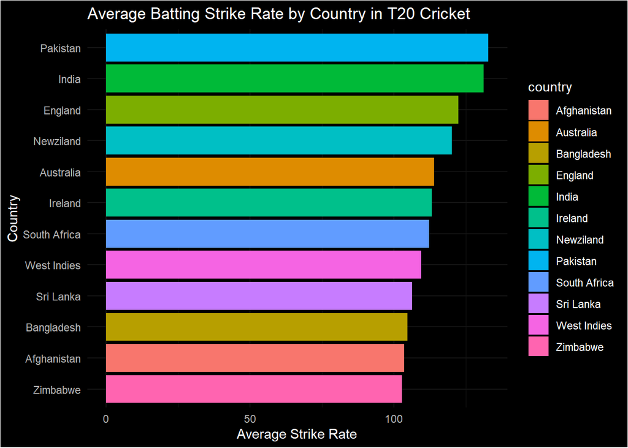

```r
avg_strike_rate_by_country <- t20 %>%
  group_by(country) %>%
  summarise(AverageStrikeRate = mean(strike_rate, na.rm = TRUE))

# Create a bar plot
ggplot(avg_strike_rate_by_country, aes(x = reorder(country, AverageStrikeRate), y = AverageStrikeRate, fill = country)) +
  geom_bar(stat = "identity") +
  dark_theme_minimal() +
  labs(title = "Average Batting Strike Rate by Country in T20 Cricket",
       x = "Country",
       y = "Average Strike Rate") +
  coord_flip()
```

Comments: The above bar chart shows the average batting strike rate for T20 cricket players from different countries. The strike rate is a measure of how quickly players score runs. In countries at the top, like Pakistan and India, their players tend to score faster on average than those from countries with shorter bars, like Zimbabwe and Bangladesh, at the bottom.

Role-based Performance in T20 Cricket

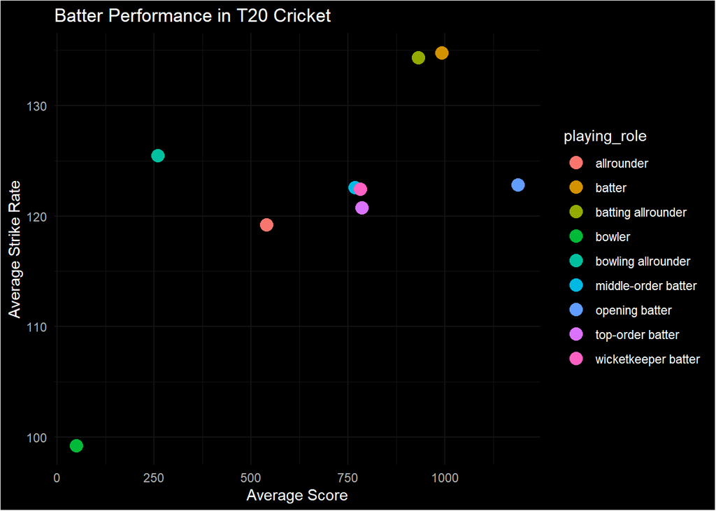

```r
#without label
avg_performance_by_role <- t20 %>%
  group_by(playing_role) %>%
  summarise(AverageScore = mean(runs, na.rm = TRUE),
            AverageStrikeRate = mean(strike_rate, na.rm = TRUE))


ggplot(avg_performance_by_role, aes(x = AverageScore, y = AverageStrikeRate, color = playing_role)) +
  geom_point(size = 4) +
  dark_theme_minimal() +
  labs(title = "Batter Performance in T20 Cricket",
       x = "Average Score",
       y = "Average Strike Rate") +
  theme(legend.position = "right")
```

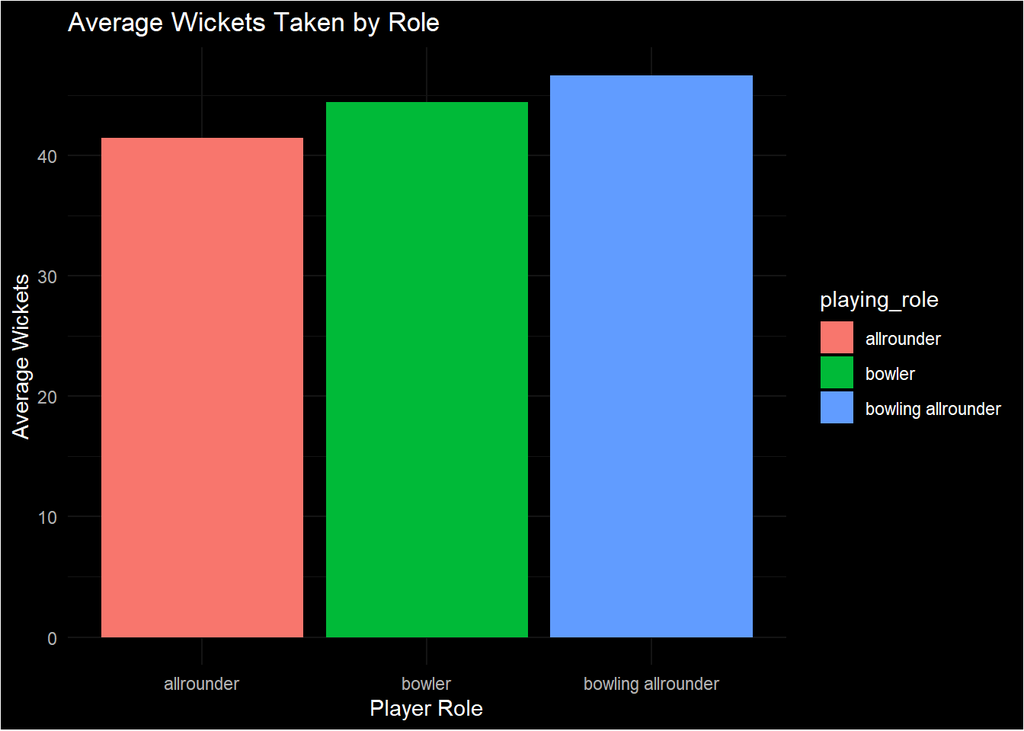

```r
average_wickets <- t20 %>%
  filter(playing_role %in%
           c("bowler", "bowling allrounder", "allrounder")) %>%
  group_by(playing_role) %>%
  summarise(AverageWickets = mean(wk_bowling, na.rm = TRUE))

# Create a bar chart
ggplot(average_wickets, aes(x = playing_role, y = AverageWickets, fill = playing_role)) +
  geom_bar(stat = "identity") +
  labs(title = "Average Wickets Taken by Role", x = "Player Role", y = "Average Wickets") +
  dark_theme_minimal()
```

Comments: This graph represents average wickets taken by playing roles, as seen, surprisingly bowling all-rounders take higher wickets than bowlers.

Bowling Performance in T20 Cricket

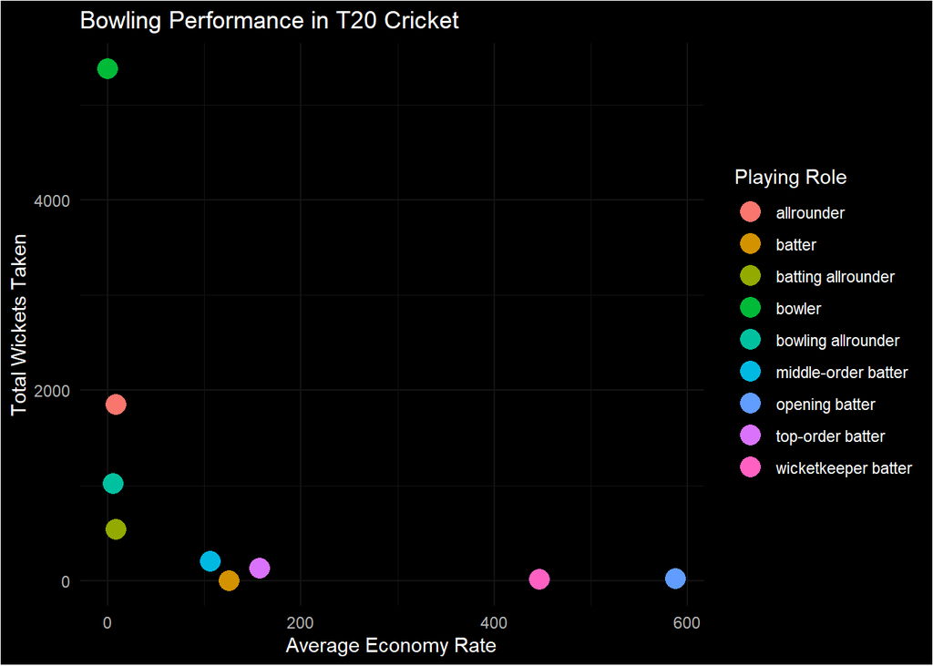

```r
bowling_data <- t20 %>%
  filter(!is.na(runs) & !is.na(wk_bowling) & !is.na(ov) & ov > 0) %>%
  group_by(playing_role) %>%
  summarise(AverageEconomyRate = mean(runs/ov, na.rm = TRUE),
            TotalWickets = sum(wk_bowling, na.rm = TRUE))

# Create the scatter plot
ggplot(bowling_data, aes(x = AverageEconomyRate, y = TotalWickets, color = playing_role)) +
  geom_point(size = 5) +
  dark_theme_minimal() +
  labs(title = "Bowling Performance in T20 Cricket",
       x = "Average Economy Rate",
       y = "Total Wickets Taken",
       color = "Playing Role")
```

Top 3 Performers in Each Role

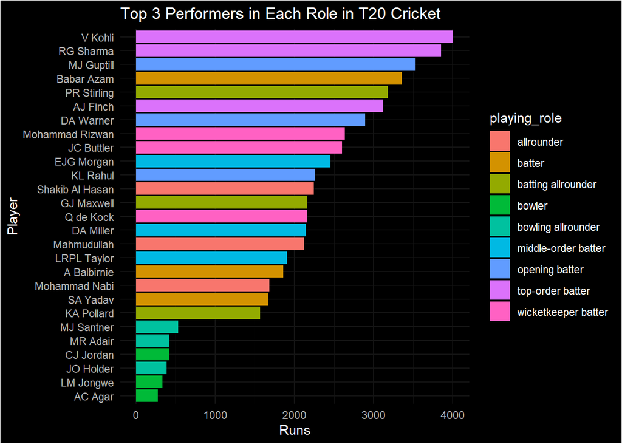

```r
top_performers <- t20 %>%
  group_by(playing_role) %>%
  top_n(3, runs) %>%
  ungroup() %>%
  arrange(desc(runs))

# Plotting
ggplot(top_performers, aes(x = reorder(name, runs), y = runs, fill = playing_role)) +
  geom_bar(stat = "identity") +
  coord_flip() +
  dark_theme_minimal() +
  labs(title = "Top 3 Performers in Each Role in T20 Cricket",
       x = "Player",
       y = "Runs")
```

Comments: This bar graph shows the top 3 players for each playing role. This graph makes us understand which player role has the top performance

Graph to see all player role:

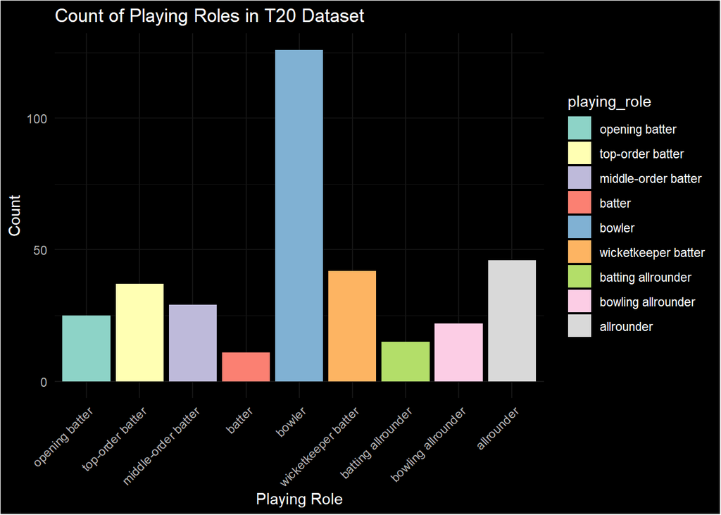

```r
library(ggplot2)
library(dplyr)


role_counts <- t20 %>%
  group_by(playing_role) %>%
  summarise(count = n())

#  playing roles
custom_order <- c("opening batter", "top-order batter", "middle-order batter", "batter",
                  "bowler",
                  "wicketkeeper batter",
                  "batting allrounder", "bowling allrounder", "allrounder")


role_counts$playing_role <- factor(role_counts$playing_role, levels = custom_order)


ggplot(role_counts, aes(x = playing_role, y = count, fill = playing_role)) +
  geom_bar(stat = "identity") +
  dark_theme_minimal() +
  theme(axis.text.x = element_text(angle = 45, hjust = 1)) +
  labs(title = "Count of Playing Roles in T20 Dataset",
       x = "Playing Role",
       y = "Count") +
  scale_fill_brewer(palette = "Set3") # This is to add different colors for readability
```

BASIC CLEANUP

```r
# Columns with 100% NA values
na_columns <- sapply(t20, function(x) mean(is.na(x))) == 1
names(na_columns[na_columns == TRUE])
```

```
## [1] "bl"            "pr_bowling"    "pr_allrounder"
```

```r
cols_with_all_NA <- sapply(t20, function(x) all(is.na(x)))
t20_cleaned <- t20[, !cols_with_all_NA]


t20_cleaned$high_score_numeric <- as.numeric(gsub("[^0-9]", "", t20_cleaned$high_score))



#specific category:
t20_cleaned <- t20_cleaned %>%
  mutate(consolidated_role = case_when(
    grepl("wicketkeeper", playing_role, ignore.case = TRUE) ~ "WicketKeeper Batter",
    grepl("batting allrounder", playing_role, ignore.case = TRUE) ~ "Batting Allrounder",
    grepl("bowling allrounder", playing_role, ignore.case = TRUE) ~ "Bowling Allrounder",
    grepl("allrounder", playing_role, ignore.case = TRUE) ~ "Allrounder",
    grepl("batter", playing_role, ignore.case = TRUE) ~ "Batter",
    grepl("bowler", playing_role, ignore.case = TRUE) ~ "Bowler",
    TRUE ~ "Other"
  ))

t20 <- t20_cleaned
```

graph it out:

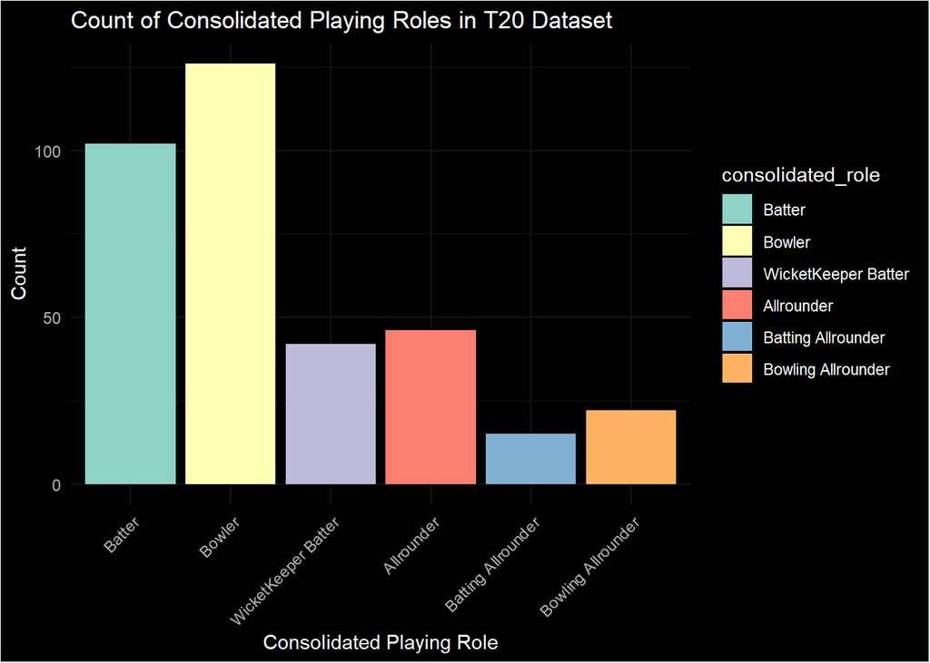

```r
library(ggplot2)
library(dplyr)

# Calculate the count of each consolidated role
consolidated_role_counts <- t20 %>%
  group_by(consolidated_role) %>%
  summarise(count = n())

# Set the factor levels for consolidated_role in the desired order
consolidated_role_counts$consolidated_role <- factor(consolidated_role_counts$consolidated_role,
                                                     levels = c("Batter", "Bowler", "WicketKeeper Batter", "Allrounder", "Batting Allrounder", "Bowling Allrounder", "Other"))

# Create the bar plot for consolidated roles
ggplot(consolidated_role_counts, aes(x = consolidated_role, y = count, fill = consolidated_role)) +
  geom_bar(stat = "identity") +
  dark_theme_minimal() +
  theme(axis.text.x = element_text(angle = 45, hjust = 1)) +
  labs(title = "Count of Consolidated Playing Roles in T20 Dataset",
       x = "Consolidated Playing Role",
       y = "Count") +
  scale_fill_brewer(palette = "Set3")  # Ensures that colors are distinct and informative
```

```r
# Summarize missing values by column
colSums(is.na(t20))
```

```
##                 id               span            matches            innings
##                  0                 43                 26                 36
##            not_out               runs         high_score      average_score
##                 36                 36                 36                 52
##         ball_faced        strike_rate               100s                 50
##                 36                 36                 36                 36
##                 0s                 4s                 6s         sp_bowling
##                 36                 36                 36                 25
##        bbi_bowling                bbm        bwa_bowling                bwe
##                116                116                116                 85
##               bwsr                 cd         fw_bowling                fwk
##                116                 85                 85                 85
##                 in                 md                 mt                 ov
##                 85                 85                  6                 85
##                 tw         wk_bowling               bbad     bbi_allrounder
##                 85                 85                169                 26
##                bta     bwa_allrounder                 ct      fw_allrounder
##                 52                149                 26                123
##                 hn                 hs                 rn                 st
##                 36                 26                 36                 26
##      wk_allrounder      sp_allrounder               name             gender
##                123                 26                  0                  0
##       bating_style      bowling_style       playing_role         country_id
##                  0                 38                  0                  0
##            country high_score_numeric  consolidated_role
##                  0                 36                  0
```

```r
t20 <- t20 %>% mutate(across(where(is.numeric), ~replace(., is.na(.), 0)))

t20
```

| id | span | matches | innings | not_out | runs | high_score | average_score | ball_faced | strike_rate | 100s | 50 | 0s | 4s | 6s | sp_bowling | bbi_bowling | bbm | bwa_bowling | bwe | bwsr | cd | fw_bowling | fwk | in | md | mt | ov | tw | wk_bowling | … |
| --- | --- | --- | --- | --- | --- | --- | --- | --- | --- | --- | --- | --- | --- | --- | --- | --- | --- | --- | --- | --- | --- | --- | --- | --- | --- | --- | --- | --- | --- | --- |
| 5334 | 2011-2022 | 103 | 103 | 12 | 3120 | 172 | 34.28 | 2189 | 142.53 | 2 | 19 | 8 | 309 | 125 | 2013-2022 | 2-Jan | 2-Jan | 64.75 | 5.47 | 71.0 | 259 | 0 | 0 | 21 | 0 | 146 | 47.2 | 0 | 4 | … |
| 8608 | 2007-2009 | 19 | 4 | 3 | 1 | 1* | 1.00 | 2 | 50.00 | 0 | 0 | 1 | 0 | 0 | 2002-2015 | 23-May | 23-May | 29.22 | 4.92 | 35.6 | 7861 | 2 | 11 | 191 | 125 | 194 | 1597.2 | 0 | 269 | … |
| 8917 | 2014-2022 | 71 | 61 | 15 | 1044 | 72* | 22.69 | 716 | 145.81 | 0 | 7 | 9 | 82 | 55 | 2014-2023 | Apr-46 | Apr-46 | 50.31 | 5.31 | 56.8 | 4830 | 0 | 1 | 116 | 11 | 126 | 909.0 | 0 | 96 | … |
| 10617 | 2006-2014 | 56 | 26 | 10 | 118 | 18* | 7.37 | 118 | 100.00 | 0 | 0 | 2 | 7 | 3 | 2006-2016 | 23-May | 23-May | 30.13 | 5.26 | 34.3 | 5364 | 1 | 9 | 121 | 56 | 121 | 1018.1 | 0 | 178 | … |
| 24598 | 2009-2022 | 115 | 107 | 21 | 2458 | 91 | 28.58 | 1805 | 136.17 | 0 | 14 | 3 | 186 | 120 | 2006-2022 | NA | NA | 0.00 | 0.00 | 0.0 | 0 | 0 | 0 | 0 | 0 | 248 | 0.0 | 0 | 0 | … |
| 25913 | 2010-2022 | 104 | 96 | 16 | 1686 | 89 | 21.07 | 1204 | 140.03 | 0 | 4 | 6 | 114 | 89 | 2009-2022 | 30-Apr | 30-Apr | 32.13 | 4.28 | 44.9 | 4628 | 0 | 4 | 131 | 43 | 136 | 1079.3 | 0 | 144 | … |
| 26421 | 2010-2022 | 65 | 19 | 12 | 184 | 31* | 26.28 | 160 | 115.00 | 0 | 0 | 0 | 17 | 4 | 2010-2022 | 25-Apr | 25-Apr | 33.49 | 4.94 | 40.6 | 5058 | 0 | 1 | 111 | 36 | 113 | 1023.3 | 0 | 151 | … |
| 28235 | 2011-2021 | 68 | 66 | 3 | 1759 | 92 | 27.92 | 1392 | 126.36 | 0 | 11 | 2 | 191 | 50 | 2010-2022 | NA | NA | 0.00 | 0.00 | 0.0 | 0 | 0 | 0 | 0 | 0 | 167 | 0.0 | 0 | 0 | … |
| 30045 | 2006-2022 | 60 | 48 | 22 | 686 | 55 | 26.38 | 481 | 142.61 | 0 | 1 | 3 | 71 | 28 | 2004-2019 | NA | NA | 0.00 | 0.00 | 0.0 | 0 | 0 | 0 | 0 | 0 | 94 | 0.0 | 0 | 0 | … |
| 32540 | NA | 0 | 0 | 0 | 0 | NA | 0.00 | 0 | 0.00 | 0 | 0 | 0 | 0 | 0 | 2013-2014 | NA | NA | 0.00 | 0.00 | 0.0 | 0 | 0 | 0 | 0 | 0 | 5 | 0.0 | 0 | 0 | … |

[output cut: 343 more lines]

Batting data

```r
#batterS_only <-batters_only[, c("high_score","not_out", "runs", "average_score", "strike_rate","ball_faced", "100s", "50","4s","0s","6s", "high_score_numeric")]
#So the face faced by each player are different and this can impact any century, boundaries and not out rate. First lets make it balanced.

#batters_only <- t20[t20$consolidated_role == "Batter", ]
#batters_only$boundary_rate <- with(batters_only, (`4s` + `6s`) / ball_faced)
#batters_only$century_rate <- with(batters_only, `100s` / innings)
#batters_only$not_out_rate <- with(batters_only, not_out / innings)
#batting_data <- batters_only[, c("boundary_rate", "century_rate", "not_out_rate",
                                         #"average_score", "strike_rate", "high_score_numeric")]

#lots of nan

# Calculate boundary rate, avoiding division by zero
batters_only <- t20[t20$consolidated_role == "Batter", ]

batters_only$boundary_rate <- with(batters_only, ifelse(ball_faced > 0, (`4s` + `6s`) / ball_faced, 0))
batters_only$century_rate <- with(batters_only, ifelse(innings > 0, `100s` / innings, 0))
batters_only$not_out_rate <- with(batters_only, ifelse(innings > 0, not_out / innings, 0))
batting_data <- batters_only[, c("boundary_rate", "century_rate", "not_out_rate",
                                 "average_score", "strike_rate", "high_score_numeric")]
```

```r
# Normalizing the batting data
str(batting_data)
```

```
## 'data.frame':    102 obs. of  6 variables:
##  $ boundary_rate     : num  0.198 0.17 0.173 0 0.192 ...
##  $ century_rate      : num  0.0194 0 0 0 0.0286 ...
##  $ not_out_rate      : num  0.1165 0.1963 0.0455 0 0.1214 ...
##  $ average_score     : num  34.3 28.6 27.9 0 31.3 ...
##  $ strike_rate       : num  143 136 126 0 139 ...
##  $ high_score_numeric: num  172 91 92 0 118 63 0 28 67 68 ...
```

```r
batting_data$high_score_numeric <- as.numeric(gsub("[^0-9.]", "", batting_data$high_score_numeric))

normalized_batting_data <- scale(batting_data)
```

```r
library(cluster)

# silhouette method
sil_width <- numeric(10)

for (k in 2:10) {
  km <- kmeans(normalized_batting_data, centers=k)
  ss <- silhouette(km$cluster, dist(normalized_batting_data))
  sil_width[k] <- mean(ss[, "sil_width"])
}

# number of clusters
k <- which.max(sil_width)
print(paste("The optimal number of clusters is:", k))
```

```
## [1] "The optimal number of clusters is: 2"
```

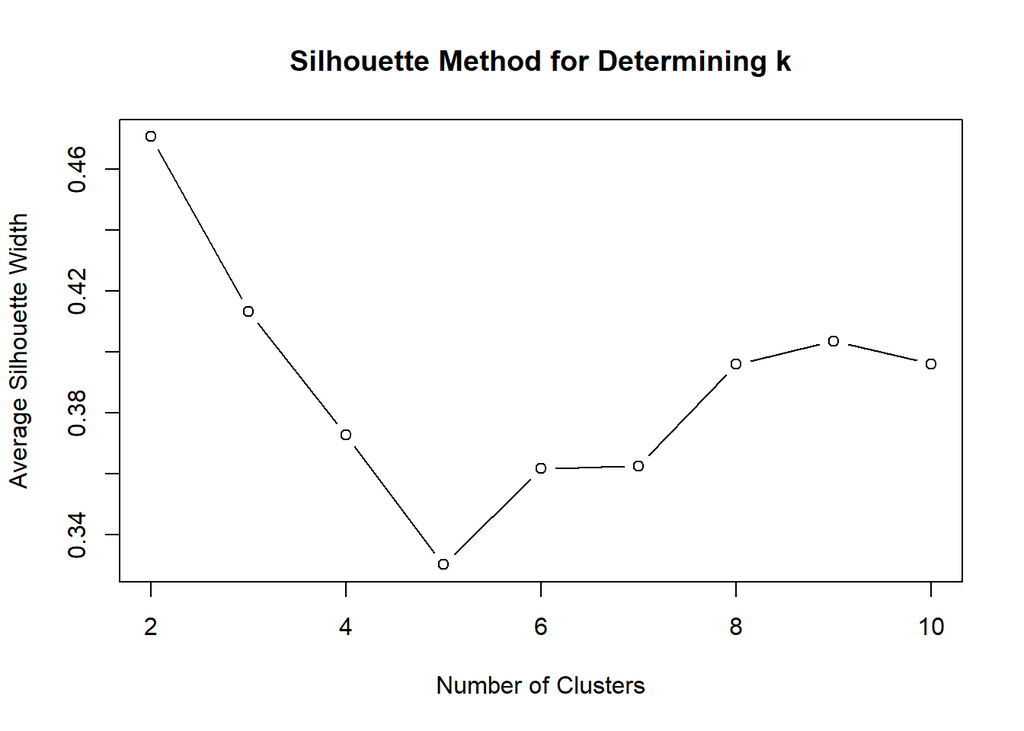

```r
# Plot the silhouette widths
plot(2:10, sil_width[-1], type='b', xlab="Number of Clusters", ylab="Average Silhouette Width", main="Silhouette Method for Determining k")
```

K- means Clustering

```r
set.seed(123)
k <- 2
final_kmeans <- kmeans(normalized_batting_data, centers=k)

# Assign cluster labels based on the silhouette method
batting_data$cluster <- as.factor(final_kmeans$cluster)
```

Visuals:

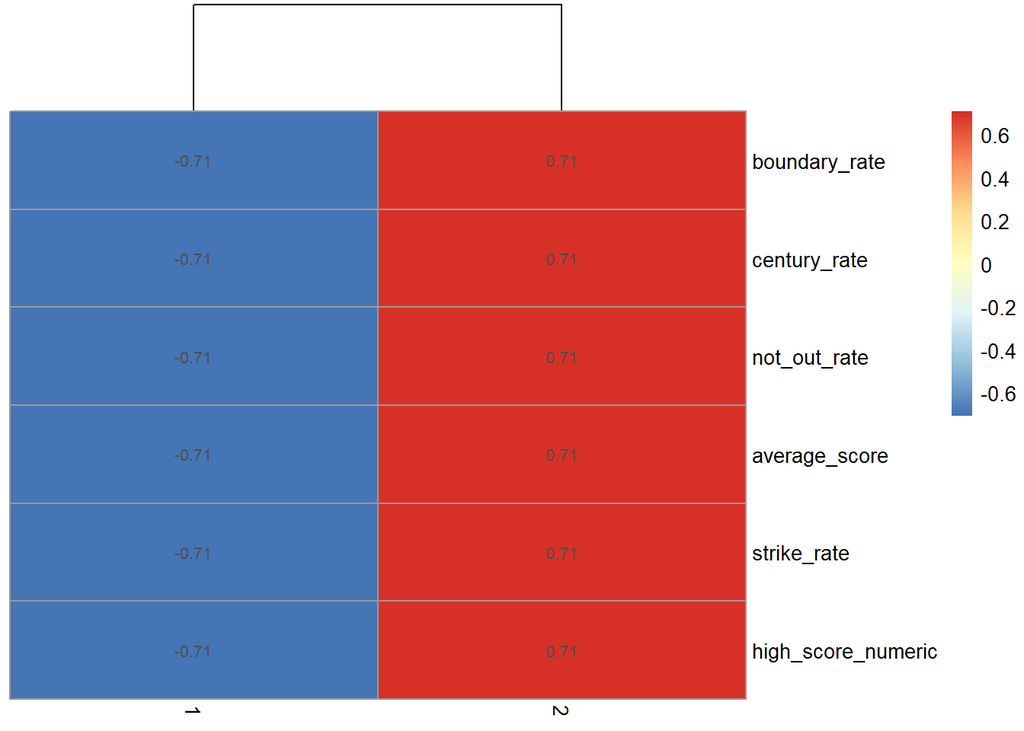

```r
library(pheatmap)
cluster_centers_df <- t(as.data.frame(final_kmeans$centers))

#heatmap
pheatmap(cluster_centers_df,
         display_numbers = TRUE,
         scale = "row",
         cluster_rows = FALSE)
```

```r
library(dplyr)


cluster_summary_batting <- batting_data %>%
  group_by(cluster) %>%
  summarise_all(mean, na.rm = TRUE)

print(cluster_summary_batting)
```

```
## # A tibble: 2 × 7
##   cluster boundary_rate century_rate not_out_rate average_score strike_rate
##   <fct>           <dbl>        <dbl>        <dbl>         <dbl>       <dbl>
## 1 1              0.0328      0            0.00924          3.71        31.0
## 2 2              0.158       0.00773      0.144           26.2        126.
## # ℹ 1 more variable: high_score_numeric <dbl>
```

```r
cluster_assignments <- final_kmeans$cluster
batters_only$cluster <- as.factor(cluster_assignments)
batters_only
```

|  | id | span | matches | innings | not_out | runs | high_score | average_score | ball_faced | strike_rate | 100s | 50 | 0s | 4s | 6s | sp_bowling | bbi_bowling | bbm | bwa_bowling | bwe | bwsr | cd | fw_bowling | fwk | in | md | mt | ov | tw | … |
| --- | --- | --- | --- | --- | --- | --- | --- | --- | --- | --- | --- | --- | --- | --- | --- | --- | --- | --- | --- | --- | --- | --- | --- | --- | --- | --- | --- | --- | --- | --- |
| 1 | 5334 | 2011-2022 | 103 | 103 | 12 | 3120 | 172 | 34.28 | 2189 | 142.53 | 2 | 19 | 8 | 309 | 125 | 2013-2022 | 2-Jan | 2-Jan | 64.75 | 5.47 | 71.0 | 259 | 0 | 0 | 21 | 0 | 146 | 47.2 | 0 | … |
| 5 | 24598 | 2009-2022 | 115 | 107 | 21 | 2458 | 91 | 28.58 | 1805 | 136.17 | 0 | 14 | 3 | 186 | 120 | 2006-2022 | NA | NA | 0.00 | 0.00 | 0.0 | 0 | 0 | 0 | 0 | 0 | 248 | 0.0 | 0 | … |
| 8 | 28235 | 2011-2021 | 68 | 66 | 3 | 1759 | 92 | 27.92 | 1392 | 126.36 | 0 | 11 | 2 | 191 | 50 | 2010-2022 | NA | NA | 0.00 | 0.00 | 0.0 | 0 | 0 | 0 | 0 | 0 | 167 | 0.0 | 0 | … |
| 10 | 32540 | NA | 0 | 0 | 0 | 0 | NA | 0.00 | 0 | 0.00 | 0 | 0 | 0 | 0 | 0 | 2013-2014 | NA | NA | 0.00 | 0.00 | 0.0 | 0 | 0 | 0 | 0 | 0 | 5 | 0.0 | 0 | … |
| 11 | 34102 | 2007-2022 | 148 | 140 | 17 | 3853 | 118 | 31.32 | 2767 | 139.24 | 4 | 29 | 10 | 348 | 182 | 2007-2023 | 27-Feb | 27-Feb | 64.37 | 5.21 | 74.1 | 515 | 0 | 0 | 38 | 2 | 241 | 98.5 | 0 | … |
| 12 | 38699 | 2006-2020 | 102 | 94 | 21 | 1909 | 63 | 26.15 | 1560 | 122.37 | 0 | 7 | 6 | 121 | 71 | 2006-2022 | NA | NA | 0.00 | 5.00 | 0.0 | 35 | 0 | 0 | 4 | 0 | 236 | 7.0 | 0 | … |
| 13 | 39037 | NA | 0 | 0 | 0 | 0 | NA | 0.00 | 0 | 0.00 | 0 | 0 | 0 | 0 | 0 | 2011-2018 | 26-Feb | 26-Feb | 65.00 | 6.04 | 64.5 | 260 | 0 | 0 | 14 | 0 | 53 | 43.0 | 0 | … |
| 14 | 40250 | 2007-2010 | 24 | 17 | 6 | 194 | 28 | 17.63 | 169 | 114.79 | 0 | 0 | 1 | 7 | 7 | 2007-2015 | 8-Jan | 8-Jan | 75.40 | 5.68 | 79.6 | 377 | 0 | 0 | 13 | 0 | 38 | 66.2 | 0 | … |
| 18 | 55354 | 2006-2020 | 36 | 35 | 0 | 667 | 67 | 19.05 | 609 | 109.52 | 0 | 5 | 4 | 78 | 13 | 2005-2023 | 25-Apr | 25-Apr | 46.60 | 5.82 | 47.9 | 1631 | 0 | 1 | 59 | 12 | 109 | 279.5 | 0 | … |
| 20 | 55412 | 2010-2023 | 59 | 58 | 3 | 1232 | 68* | 22.40 | 1162 | 106.02 | 0 | 7 | 1 | 125 | 26 | 2010-2023 | NA | NA | 0.00 | 0.00 | 0.0 | 0 | 0 | 0 | 0 | 0 | 107 | 0.0 | 0 | … |

[output cut: 92 more lines]

MODELLING: BATTING ADD the result dataset:BATTING

```r
batters_only
```

|  | id | span | matches | innings | not_out | runs | high_score | average_score | ball_faced | strike_rate | 100s | 50 | 0s | 4s | 6s | sp_bowling | bbi_bowling | bbm | bwa_bowling | bwe | bwsr | cd | fw_bowling | fwk | in | md | mt | ov | tw | … |
| --- | --- | --- | --- | --- | --- | --- | --- | --- | --- | --- | --- | --- | --- | --- | --- | --- | --- | --- | --- | --- | --- | --- | --- | --- | --- | --- | --- | --- | --- | --- |
| 1 | 5334 | 2011-2022 | 103 | 103 | 12 | 3120 | 172 | 34.28 | 2189 | 142.53 | 2 | 19 | 8 | 309 | 125 | 2013-2022 | 2-Jan | 2-Jan | 64.75 | 5.47 | 71.0 | 259 | 0 | 0 | 21 | 0 | 146 | 47.2 | 0 | … |
| 5 | 24598 | 2009-2022 | 115 | 107 | 21 | 2458 | 91 | 28.58 | 1805 | 136.17 | 0 | 14 | 3 | 186 | 120 | 2006-2022 | NA | NA | 0.00 | 0.00 | 0.0 | 0 | 0 | 0 | 0 | 0 | 248 | 0.0 | 0 | … |
| 8 | 28235 | 2011-2021 | 68 | 66 | 3 | 1759 | 92 | 27.92 | 1392 | 126.36 | 0 | 11 | 2 | 191 | 50 | 2010-2022 | NA | NA | 0.00 | 0.00 | 0.0 | 0 | 0 | 0 | 0 | 0 | 167 | 0.0 | 0 | … |
| 10 | 32540 | NA | 0 | 0 | 0 | 0 | NA | 0.00 | 0 | 0.00 | 0 | 0 | 0 | 0 | 0 | 2013-2014 | NA | NA | 0.00 | 0.00 | 0.0 | 0 | 0 | 0 | 0 | 0 | 5 | 0.0 | 0 | … |
| 11 | 34102 | 2007-2022 | 148 | 140 | 17 | 3853 | 118 | 31.32 | 2767 | 139.24 | 4 | 29 | 10 | 348 | 182 | 2007-2023 | 27-Feb | 27-Feb | 64.37 | 5.21 | 74.1 | 515 | 0 | 0 | 38 | 2 | 241 | 98.5 | 0 | … |
| 12 | 38699 | 2006-2020 | 102 | 94 | 21 | 1909 | 63 | 26.15 | 1560 | 122.37 | 0 | 7 | 6 | 121 | 71 | 2006-2022 | NA | NA | 0.00 | 5.00 | 0.0 | 35 | 0 | 0 | 4 | 0 | 236 | 7.0 | 0 | … |
| 13 | 39037 | NA | 0 | 0 | 0 | 0 | NA | 0.00 | 0 | 0.00 | 0 | 0 | 0 | 0 | 0 | 2011-2018 | 26-Feb | 26-Feb | 65.00 | 6.04 | 64.5 | 260 | 0 | 0 | 14 | 0 | 53 | 43.0 | 0 | … |
| 14 | 40250 | 2007-2010 | 24 | 17 | 6 | 194 | 28 | 17.63 | 169 | 114.79 | 0 | 0 | 1 | 7 | 7 | 2007-2015 | 8-Jan | 8-Jan | 75.40 | 5.68 | 79.6 | 377 | 0 | 0 | 13 | 0 | 38 | 66.2 | 0 | … |
| 18 | 55354 | 2006-2020 | 36 | 35 | 0 | 667 | 67 | 19.05 | 609 | 109.52 | 0 | 5 | 4 | 78 | 13 | 2005-2023 | 25-Apr | 25-Apr | 46.60 | 5.82 | 47.9 | 1631 | 0 | 1 | 59 | 12 | 109 | 279.5 | 0 | … |
| 20 | 55412 | 2010-2023 | 59 | 58 | 3 | 1232 | 68* | 22.40 | 1162 | 106.02 | 0 | 7 | 1 | 125 | 26 | 2010-2023 | NA | NA | 0.00 | 0.00 | 0.0 | 0 | 0 | 0 | 0 | 0 | 107 | 0.0 | 0 | … |

[output cut: 92 more lines]

```r
wc_results <-  read_csv("T20WorldCupsResults.csv")
head(wc_results)
```

| Year | Team 1 | Team 2 | Winner | WC winner | Venue | Date | Match Type | Host Nation |
| --- | --- | --- | --- | --- | --- | --- | --- | --- |
| 2007 | WI | SA | SA | IND | Johannesburg | 11 Sep | League Stage | SA |
| 2007 | KEN | NZ | NZ | IND | Durban | 12 Sep | League Stage | SA |
| 2007 | PAK | SCO | PAK | IND | Durban | 12 Sep | League Stage | SA |
| 2007 | AUS | ZIM | ZIM | IND | Cape Town | 12 Sep | League Stage | SA |
| 2007 | WI | BAN | BAN | IND | Johannesburg | 13 Sep | League Stage | SA |
| 2007 | ENG | ZIM | ENG | IND | Cape Town | 13 Sep | League Stage | SA |

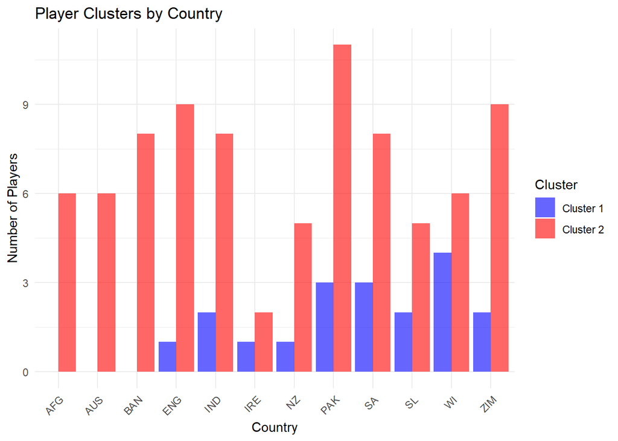

```r
player_clusters_by_team <- batters_only %>%
  group_by(country, cluster) %>%
  summarise(number_of_players = n(), .groups = 'drop')%>%
  spread(cluster, number_of_players, fill = 0)%>%
    mutate(country_abbreviation = case_when(
    country == "Afghanistan" ~ "AFG",
    country == "Australia" ~ "AUS",
    country == "Bangladesh" ~ "BAN",
    country == "England" ~ "ENG",
    country == "India" ~ "IND",
    country == "Ireland" ~ "IRE",
    country == "Newziland" ~ "NZ",
    country == "Pakistan" ~ "PAK",
    country == "South Africa" ~ "SA",
    country == "Sri Lanka" ~ "SL",
    country == "West Indies" ~ "WI",
    country == "Zimbabwe" ~ "ZIM",
    TRUE ~ country
  ))

library(ggplot2)
library(tidyr)

# Reshape the data to long format
player_clusters_long <- player_clusters_by_team %>%
  pivot_longer(cols = c(`1`, `2`), names_to = "cluster", values_to = "number_of_players") %>%
  mutate(cluster = recode(cluster, `1` = "Cluster 1", `2` = "Cluster 2")) # rename clusters

# Now plot using the reshaped data
ggplot(player_clusters_long, aes(x = country_abbreviation, y = number_of_players, fill = cluster)) +
  geom_bar(stat = "identity", position = "dodge", alpha = 0.6) +
  scale_fill_manual(values = c("Cluster 1" = "blue", "Cluster 2" = "red"),
                    name = "Cluster") +
  labs(title = "Player Clusters by Country",
       x = "Country",
       y = "Number of Players") +
  theme_minimal() +
  theme(axis.text.x = element_text(angle = 45, hjust = 1)) +
  theme(legend.position = "right")
```

```r
# Join the player_clusters_by_team with the World Cup results data for Team 1
wc_results <- wc_results %>%
  left_join(player_clusters_by_team, by = c("Team 1" = "country_abbreviation"))

wc_results <- wc_results %>%
  left_join(player_clusters_by_team, by = c("Team 2" = "country_abbreviation"), suffix = c("_Team1", "_Team2"))

head(wc_results)
```

| Year | Team 1 | Team 2 | Winner | WC winner | Venue | Date | Match Type | Host Nation | country_Team1 | 1_Team1 | 2_Team1 | country_Team2 | 1_Team2 | 2_Team2 |
| --- | --- | --- | --- | --- | --- | --- | --- | --- | --- | --- | --- | --- | --- | --- |
| 2007 | WI | SA | SA | IND | Johannesburg | 11 Sep | League Stage | SA | West Indies | 4 | 6 | South Africa | 3 | 8 |
| 2007 | KEN | NZ | NZ | IND | Durban | 12 Sep | League Stage | SA | NA | NA | NA | Newziland | 1 | 5 |
| 2007 | PAK | SCO | PAK | IND | Durban | 12 Sep | League Stage | SA | Pakistan | 3 | 11 | NA | NA | NA |
| 2007 | AUS | ZIM | ZIM | IND | Cape Town | 12 Sep | League Stage | SA | Australia | 0 | 6 | Zimbabwe | 2 | 9 |
| 2007 | WI | BAN | BAN | IND | Johannesburg | 13 Sep | League Stage | SA | West Indies | 4 | 6 | Bangladesh | 0 | 8 |
| 2007 | ENG | ZIM | ENG | IND | Cape Town | 13 Sep | League Stage | SA | England | 1 | 9 | Zimbabwe | 2 | 9 |

```r
wc_results <- wc_results %>%
  drop_na()
```

Modelling

```r
# Load required libraries
library(caret)
library(dplyr)

wc_results$Team1 <- as.character(wc_results$`Team 1`)
wc_results$Team2 <- as.character(wc_results$`Team 2`)

# binary target variable indicating whether the team of interest won
wc_results$winner_binary <- ifelse(wc_results$Winner == wc_results$`Team 1`, 1, 0)

# Convert Team1 and Team2 to factors if they are categorical
wc_results$Team1 <- as.factor(wc_results$Team1)
wc_results$Team2 <- as.factor(wc_results$Team2)

# Step 2: Split the data into training and testing sets
set.seed(123) # for reproducibility
training_indices <- sample(1:nrow(wc_results), size = 0.7 * nrow(wc_results))
train_data <- wc_results[training_indices, ]
test_data <- wc_results[-training_indices, ]

library(splitstackshape)
dat <- stratified(wc_results, group = c("1_Team1", "2_Team1", "1_Team2", "2_Team2"), size = 0.2, bothSets = TRUE)

train_data <- dat[[2]]
test_data <- dat[[1]]

# logistic regression model
model <- glm(winner_binary ~ `1_Team1` + `2_Team1` + `1_Team2` + `2_Team2`, data = train_data, family = "binomial")

# Predict on test data
predictions <- predict(model, newdata = test_data, type = "response")
predicted_classes <- ifelse(predictions > 0.6, 1, 0)

# Convert predictions
test_data$winner_binary <- factor(test_data$winner_binary, levels = c(0, 1))
predicted_classes <- factor(predicted_classes, levels = c(0, 1))

lg_conf_matrix <- confusionMatrix(data = predicted_classes, reference = test_data$winner_binary)
lg_conf_df <- as.data.frame.matrix(lg_conf_matrix$table)
```

##xgboot

```r
wc_results
```

| Year | Team 1 | Team 2 | Winner | WC winner | Venue | Date | Match Type | Host Nation | country_Team1 | 1_Team1 | 2_Team1 | country_Team2 | 1_Team2 | 2_Team2 | Team1 | Team2 | winner_binary |
| --- | --- | --- | --- | --- | --- | --- | --- | --- | --- | --- | --- | --- | --- | --- | --- | --- | --- |
| 2007 | WI | SA | SA | IND | Johannesburg | 11 Sep | League Stage | SA | West Indies | 4 | 6 | South Africa | 3 | 8 | WI | SA | 0 |
| 2007 | AUS | ZIM | ZIM | IND | Cape Town | 12 Sep | League Stage | SA | Australia | 0 | 6 | Zimbabwe | 2 | 9 | AUS | ZIM | 0 |
| 2007 | WI | BAN | BAN | IND | Johannesburg | 13 Sep | League Stage | SA | West Indies | 4 | 6 | Bangladesh | 0 | 8 | WI | BAN | 0 |
| 2007 | ENG | ZIM | ENG | IND | Cape Town | 13 Sep | League Stage | SA | England | 1 | 9 | Zimbabwe | 2 | 9 | ENG | ZIM | 1 |
| 2007 | ENG | AUS | AUS | IND | Cape Town | 14 Sep | League Stage | SA | England | 1 | 9 | Australia | 0 | 6 | ENG | AUS | 0 |
| 2007 | IND | PAK | IND | IND | Durban | 14 Sep | League Stage | SA | India | 2 | 8 | Pakistan | 3 | 11 | IND | PAK | 1 |
| 2007 | NZ | SL | SL | IND | Johannesburg | 15 Sep | League Stage | SA | Newziland | 1 | 5 | Sri Lanka | 2 | 5 | NZ | SL | 0 |
| 2007 | BAN | SA | SA | IND | Cape Town | 15 Sep | League Stage | SA | Bangladesh | 0 | 8 | South Africa | 3 | 8 | BAN | SA | 0 |
| 2007 | IND | NZ | NZ | IND | Johannesburg | 16 Sep | League Stage | SA | India | 2 | 8 | Newziland | 1 | 5 | IND | NZ | 0 |
| 2007 | BAN | AUS | AUS | IND | Cape Town | 16 Sep | League Stage | SA | Bangladesh | 0 | 8 | Australia | 0 | 6 | BAN | AUS | 0 |

[output cut: 185 more lines]

```r
library(xgboost)

wc_results$winner_binary <- ifelse(wc_results$Winner == wc_results$`Team 1`, 1, 0)


numeric_predictors <- wc_results[, c("1_Team1", "2_Team1", "1_Team2", "2_Team2")]


set.seed(123)
training_indices <- sample(1:nrow(wc_results), size = 0.7 * nrow(wc_results))
train_data <- numeric_predictors[training_indices, ]
test_data <- numeric_predictors[-training_indices, ]

train_labels <- wc_results$winner_binary[training_indices]
test_labels <- wc_results$winner_binary[-training_indices]

# Create DMatrix objects for XGBoost
dtrain <- xgb.DMatrix(data = as.matrix(train_data), label = train_labels)
dtest <- xgb.DMatrix(data = as.matrix(test_data), label = test_labels)


params <- list(
  booster = "gbtree",
  objective = "binary:logistic",
  eta = 0.3,
  max_depth = 6,
  subsample = 0.8,
  colsample_bytree = 0.8
)

# Train the model
xgb_model <- xgb.train(params = params, data = dtrain, nrounds = 100)

#Make predictions
predictions <- predict(xgb_model, dtest)
predicted_classes <- ifelse(predictions > 0.6, 1, 0)

#Convert predictions to factors for the confusion matrix calculation
predicted_classes <- factor(predicted_classes, levels = c(0, 1))
test_labels <- factor(test_labels, levels = c(0, 1))


xg_conf_matrix <- confusionMatrix(predicted_classes, test_labels)
print(xg_conf_matrix)
```

```
## Confusion Matrix and Statistics
##
##           Reference
## Prediction  0  1
##          0  7 17
##          1  8 27
##
##                Accuracy : 0.5763
##                  95% CI : (0.4407, 0.7039)
##     No Information Rate : 0.7458
##     P-Value [Acc > NIR] : 0.9986
##
##                   Kappa : 0.067
##
##  Mcnemar's Test P-Value : 0.1096
##
##             Sensitivity : 0.4667
##             Specificity : 0.6136
##          Pos Pred Value : 0.2917
##          Neg Pred Value : 0.7714
##              Prevalence : 0.2542
##          Detection Rate : 0.1186
##    Detection Prevalence : 0.4068
##       Balanced Accuracy : 0.5402
##
##        'Positive' Class : 0
##
```

SHAP GRAPH

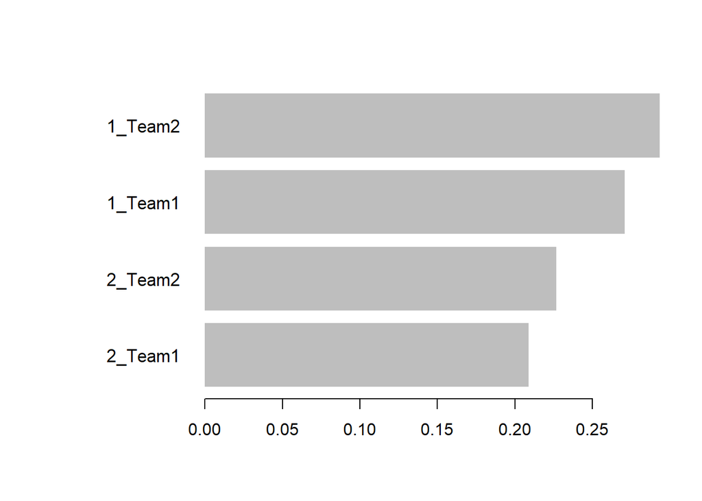

```r
# Get feature importance
importance <- xgb.importance(feature_names = colnames(xg_conf_matrix), model = xgb_model)
xgb.plot.importance(importance)
```

```r
source("a_insights_shap_functions.r")
library(shapper)
m_dat <- as.matrix(train_data)

shap_result <- shap.score.rank(xgb_model = xgb_model,
                X_train = m_dat,
                shap_approx = FALSE)
```

```
## make SHAP score by decreasing order
```

```r
shap_long <- shap.prep(shap = shap_result,
                       X_train = m_dat,
                       top_n = 4)
```

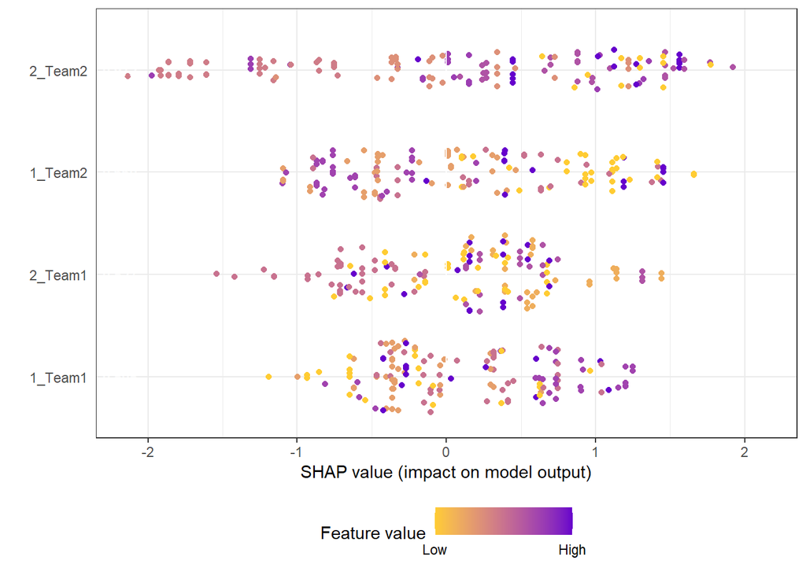

```r
plot.shap.summary(data_long = shap_long)
```